# Analysing EQ-5D data

## Introduction

This vignette demonstrates how `eq5dsuite` supports the full EQ-5D analytical workflow recommended by Devlin et al. (2020), using the NHS Patient Reported Outcome Measures (PROMs) dataset bundled with the package. The dataset includes patients undergoing hip replacement, knee replacement, groin hernia repair, and varicose vein surgery, who completed the EQ-5D-3L before and after their procedure.

```r
# The example dataset is bundled with the package
data(example_data)
head(example_data)
```

```
#>    id    time mo sc ua pd ad vas       procedure    year ageband gender
#> 1  86  Pre-op  2  2  3  3  1  85 Hip Replacement 2013/14    <NA>   <NA>
#> 2  86 Post-op  1  1  1  1  1  88 Hip Replacement 2013/14    <NA>   <NA>
#> 3 121  Pre-op  2  2  2  2  2  85 Hip Replacement 2013/14    <NA>   <NA>
#> 4 121 Post-op  1  1  2  2  2  70 Hip Replacement 2013/14    <NA>   <NA>
#> 5 123  Pre-op  2  2  2  2  1  35 Hip Replacement 2013/14    <NA>   <NA>
#> 6 123 Post-op  2  2  2  2  2  65 Hip Replacement 2013/14    <NA>   <NA>
```

## Worked example 1: Hip replacement outcomes

This example illustrates a typical single-group longitudinal workflow, addressing three practical questions: which problems do patients report before surgery, how does health change following the procedure, and how large is the overall health gain?

### Data preparation

```r
dim_names <- c("mo", "sc", "ua", "pd", "ad")

# Subset to hip replacement patients
hip_data <- example_data[example_data$procedure == "Hip Replacement", ]

# Add profile code and EQ-5D value
hip_data$profile_code <- toEQ5Dindex(
  x         = hip_data,
  dim.names = dim_names
)
hip_data$value <- eq5d3l(
  hip_data[, dim_names],
  country   = "GB",
  dim.names = dim_names
)
# Pre-operative subset
hip_preop <- hip_data[hip_data$time == "Pre-op", ]
```

### Pre-operative profile distribution

```r
eq5d_profile_level_summary(
  df           = hip_preop,
  names_eq5d   = dim_names,
  eq5d_version = "3L"
)
```

[output not shown]

### Most common health states

```r
eq5d_profile_top_states(
  df           = hip_preop,
  names_eq5d   = dim_names,
  eq5d_version = "3L",
  n            = 5
)
```

[output not shown]

### Informativity: Shannon’s indices

How much of the classification system does this sample actually use? Shannon’s index `H'` measures that in bits, and `J'` expresses it as a fraction of the maximum the instrument allows, so it is comparable between samples and between instruments.

```r
eq5d_profile_shannon(
  df           = hip_data,
  names_eq5d   = dim_names,
  eq5d_version = "3L",
  name_fu      = "time",
  levels_fu    = c("Pre-op", "Post-op")
)
```

[output not shown]

### Change between time points: PCHC

The Paretian Classification of Health Change (PCHC) classifies each patient as Better, Worse, Mixed, or No Change between time points. All plot functions in `eq5dsuite` return ggplot2 objects that can be customised directly:

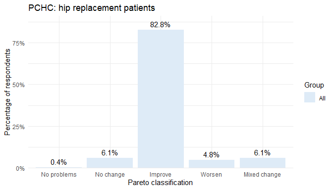

PCHC classification for hip replacement patients.

```r
eq5d_profile_pchc_by_group_plot(
  df         = hip_data,
  name_id    = "id",
  names_eq5d = dim_names,
  name_fu    = "time",
  levels_fu  = c("Pre-op", "Post-op")
)$p +
  ggplot2::labs(
    title = "PCHC: hip replacement patients",
    x     = NULL,
    y     = "Percentage of respondents"
  ) +
  ggplot2::theme_minimal()
```

### Dimensions driving improvement

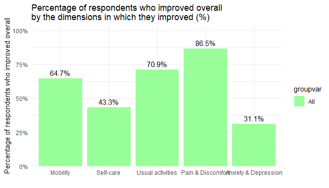

Dimensions improved among patients classified as Better.

```r
eq5d_profile_better_dimensions_by_group_plot(
  df         = hip_data,
  name_id    = "id",
  names_eq5d = dim_names,
  name_fu    = "time",
  levels_fu  = c("Pre-op", "Post-op")
)$p +
  ggplot2::theme_minimal()
```

### EQ-5D value summary

The `eq5d_utility_*` functions analyse a column of EQ-5D values rather than calculating one, so the values are added first. That keeps the choice of value set in one visible place, and lets the same analysis run on values that came from anywhere else — a crosswalk, the NICE DSU mapping, or another package.

```r
hip_data$value <- eq5d3l(
  hip_data[, dim_names],
  country   = "GB",
  dim.names = dim_names
)
eq5d_utility_summary(
  df           = hip_data,
  name_utility = "value",
  name_fu      = "time",
  levels_fu    = c("Pre-op", "Post-op")
)
```

```
#>                     name        Pre-op       Post-op
#> 1                   Mean  3.654281e-01  7.927837e-01
#> 2         Standard error  7.785437e-03  5.868664e-03
#> 3                 Median  5.160000e-01  8.480001e-01
#> 4                   Mode  6.910000e-01  1.000000e+00
#> 5     Standard deviation  3.271736e-01  2.491937e-01
#> 6  Kurtosis (non-excess)  1.642925e+00  6.093719e+00
#> 7               Skewness -2.961227e-01 -1.650594e+00
#> 8                Minimum -5.940000e-01 -3.490000e-01
#> 9                Maximum  1.000000e+00  1.000000e+00
#> 10                 Range  1.594000e+00  1.349000e+00
#> 11          Observations  1.766000e+03  1.803000e+03
#> 12           Missing (n)  1.120000e+02  7.500000e+01
#> 13          Total sample  1.878000e+03  1.878000e+03
#> 14           Missing (%)  5.963791e+00  3.993610e+00
```

### EQ VAS summary

```r
eq5d_vas_summary(
  df        = hip_data,
  name_vas  = "vas",
  name_fu   = "time",
  levels_fu = c("Pre-op", "Post-op")
)
```

[output not shown]

## Worked example 2: Comparing two procedures

This example demonstrates a cross-sectional group comparison using pre-operative data from knee replacement and groin hernia patients — two groups with very different levels of pre-operative health burden.

### Data preparation

```r
# Subset to two procedures, pre-operative only
procs <- c("Knee Replacement", "Groin Hernia")
comparison_data <- example_data[
  example_data$procedure %in% procs &
  example_data$time == "Pre-op", ]

# Add profile code and EQ-5D value
comparison_data$profile_code <- toEQ5Dindex(
  x         = comparison_data,
  dim.names = dim_names
)
comparison_data$value <- eq5d3l(
  comparison_data[, dim_names],
  country   = "GB",
  dim.names = dim_names
)
```

### Profile comparison by group

```r
eq5d_profile_level_summary_by_group(
  df           = comparison_data,
  names_eq5d   = dim_names,
  name_cat     = "procedure",
  eq5d_version = "3L"
)
```

```
#> No ordering of time supplied. The time variable will be factorised according to the order in the data frame.
#> Warning: 427 EQ-5D dimension observations are not a level the instrument allows
#> and have been set to NA (out of range: 427). Each level must be a whole number
#> from 1 to 3. Fractional values are not rounded: 1.9 is neither level 1 nor
#> level 2.
#>                                        level n_Knee Replacement_mo
#> 1                                          1                   133
#> 2                                          2                  1789
#> 3                                          3                     9
#> 4                                      Total                  1931
#> 5 Number reporting any problems (levels 2+3)                  1798
#> 6                               Missing data                    65
#>   freq_Knee Replacement_mo n_Groin Hernia_mo freq_Groin Hernia_mo
#> 1              0.068876230               735          0.823068309
#> 2              0.926462973               158          0.176931691
```

[output cut: 46 more lines]

### EQ-5D value comparison

```r
eq5d_utility_summary_by_group(
  df            = comparison_data,
  name_utility  = "value",
  name_groupvar = "procedure"
)
```

```
#>             name Groin Hernia Knee Replacement   All groups
#> 1           Mean 7.877045e-01     4.039469e-01 5.262618e-01
#> 2 Standard error 6.945801e-03     7.163948e-03 6.355527e-03
#> 3         Median 7.960000e-01     5.870000e-01 6.910000e-01
#> 4           25th 7.270000e-01     8.799999e-02 1.590000e-01
#> 5           75th 1.000000e+00     6.910000e-01 7.600000e-01
#> 6              N 8.730000e+02     1.866000e+03 2.739000e+03
#> 7        Missing 2.600000e+01     1.300000e+02 1.560000e+02
```

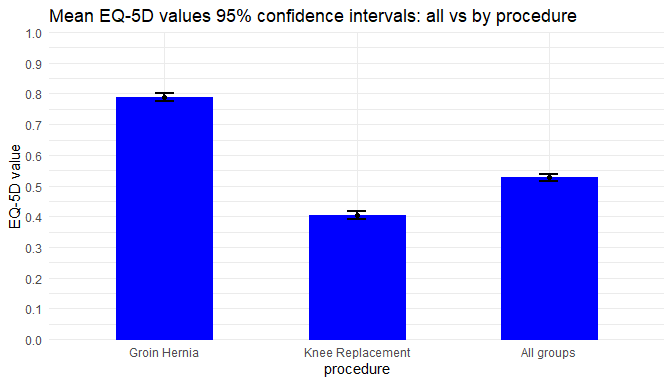

Mean pre-operative EQ-5D values by procedure group.

```r
eq5d_utility_by_group_plot(
  df            = comparison_data,
  name_utility  = "value",
  name_groupvar = "procedure"
)$p +
  ggplot2::theme_minimal()
```

### LSS analysis by group

The Level Sum Score (LSS) summarises overall severity as the sum of level scores across the five dimensions (range 5–15 for 3L, 5–25 for 5L). The plot below shows how EQ-5D values relate to LSS within each procedure group:

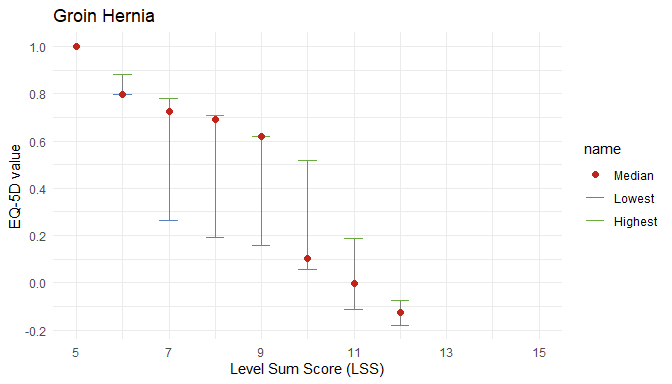

EQ-5D values by LSS — Groin Hernia.

```r
hernia_data <- comparison_data[
  comparison_data$procedure == "Groin Hernia", ]

eq5d_profile_lss_utility_plot(
  hernia_data,
  names_eq5d   = dim_names,
  name_utility = "value",
  eq5d_version = "3L"
)$p +
  ggplot2::labs(
    title = "Groin Hernia",
    x     = "Level Sum Score (LSS)",
    y     = "EQ-5D value"
  ) +
  ggplot2::scale_x_continuous(limits = c(5, 15),
                               breaks = seq(5, 15, 2)) +
  ggplot2::theme_minimal()
```

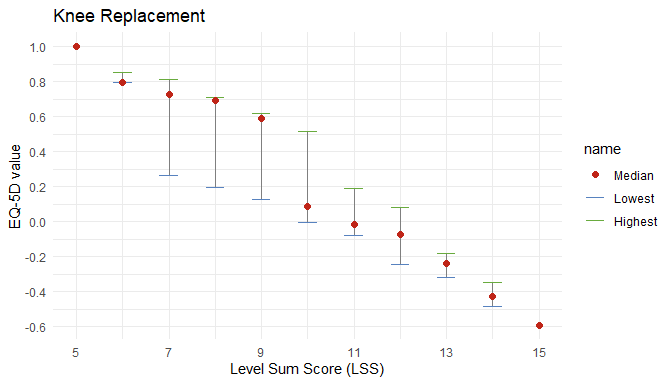

EQ-5D values by LSS — Knee Replacement.

```r
knee_data <- comparison_data[
  comparison_data$procedure == "Knee Replacement", ]

eq5d_profile_lss_utility_plot(
  knee_data,
  names_eq5d   = dim_names,
  name_utility = "value",
  eq5d_version = "3L"
)$p +
  ggplot2::labs(
    title = "Knee Replacement",
    x     = "Level Sum Score (LSS)",
    y     = "EQ-5D value"
  ) +
  ggplot2::scale_x_continuous(limits = c(5, 15),
                               breaks = seq(5, 15, 2)) +
  ggplot2::theme_minimal()
```

## Further reading

- `vignette("crosswalk-methods")` — when and how to use crosswalk methods
- `vignette("custom-value-sets")` — adding and managing custom value sets
- `vignette("update-value-sets")` — keeping value sets up to date

## References

Devlin N, Parkin D, Janssen B (2020). *Methods for Analysing and Reporting EQ-5D Data*. Springer, Cham. https://doi.org/10.1007/978-3-030-47622-9